# PR3PH_DENGUE-ANALYSIS

An Analysis of Dengue Outbreaks in the Philippines

### EXECUTIVE SUMMARY

[figure not shown]

This report provides an analysis of dengue fever in the Philippines from 2016 to 2020. Dengue is a viral infection caused by the dengue virus (DENV), transmitted to humans through the bite of infected mosquitoes. While many infected people show no symptoms, others experience high fever, severe headache, body aches, nausea, and a rash. Although most people recover within one to two weeks, some develop a severe, potentially fatal form of the disease that requires hospital care. Many even die because of it. This study aims to identify the trends of dengue outbreaks in the country during this five-year period.

It first looks at where dengue cases and deaths were concentrated in different parts of the country. We then tracked how these numbers rose and fell from month to month and year to year. From this, we learn the specific regions most severely affected and pinpoints the times of year when the danger of an outbreak is greatest.

This serves as a practical guide for action. Health departments and local governments can use these findings to make smart choices. They’ll know exactly where to send extra help, how to stock their clinics, and the best time to run mosquito prevention campaigns. This evidence helps them build stronger defenses against dengue and better protect the communities.

**LEAD ANALYST** JOMEL TOMEO

**REPORT DATE** OCTOBER 16, 2025

**ANALYSIS PERIOD** 2016-2020

DENGUE SURVEILLANCE • OUTBREAK PREVENTION • ACTIONABLE INSIGHTS • COMMUNITY PROTECTION

### Initialization of Core Libraries

```python
import numpy as np
import pandas as pd
import matplotlib.pyplot as plt
import seaborn as sns
import folium
from folium.plugins import HeatMap
from collections import Counter
import warnings
warnings.filterwarnings('ignore')
```

### Loading Datase(s) into DataFrames

- ▶ DataFrame Identifier
- ▶ Dataset File Location

```python
dengue = pd.read_csv("datasets\\dengue.csv")
dengue
```

|  | Month | Year | Region | Dengue_Cases | Dengue_Deaths |
| --- | --- | --- | --- | --- | --- |
| 0 | January | 2016 | Region I | 705 | 1 |
| 1 | February | 2016 | Region I | 374 | 0 |
| 2 | March | 2016 | Region I | 276 | 0 |
| 3 | April | 2016 | Region I | 240 | 2 |
| 4 | May | 2016 | Region I | 243 | 1 |
| ... | ... | ... | ... | ... | ... |
| 1015 | August | 2020 | BARMM | 91 | 0 |
| 1016 | September | 2020 | BARMM | 16 | 8 |
| 1017 | October | 2020 | BARMM | 13 | 9 |
| 1018 | November | 2020 | BARMM | 15 | 1 |
| 1019 | December | 2020 | BARMM | 23 | 0 |

1020 rows × 5 columns

### Descriptive Analytics

```python
dengue.describe()
```

|  | Year | Dengue_Cases | Dengue_Deaths |
| --- | --- | --- | --- |
| count | 1020.000000 | 1020.000000 | 1020.000000 |
| mean | 2018.000000 | 1124.926471 | 16.513725 |
| std | 1.414907 | 1662.608878 | 96.358215 |
| min | 2016.000000 | 10.000000 | 0.000000 |
| 25% | 2017.000000 | 247.750000 | 1.000000 |
| 50% | 2018.000000 | 582.500000 | 3.000000 |
| 75% | 2019.000000 | 1284.250000 | 7.000000 |
| max | 2020.000000 | 21658.000000 | 1651.000000 |

```python
dengue.describe().T
```

|  | count | mean | std | min | 25% | 50% | 75% | max |
| --- | --- | --- | --- | --- | --- | --- | --- | --- |
| Year | 1020.0 | 2018.000000 | 1.414907 | 2016.0 | 2017.00 | 2018.0 | 2019.00 | 2020.0 |
| Dengue_Cases | 1020.0 | 1124.926471 | 1662.608878 | 10.0 | 247.75 | 582.5 | 1284.25 | 21658.0 |
| Dengue_Deaths | 1020.0 | 16.513725 | 96.358215 | 0.0 | 1.00 | 3.0 | 7.00 | 1651.0 |

### Classify Regions into Luzon, Visayas, and Mindanao

```python
luzon_regions = ['Region I', 'Region II', 'Region III', 'Region IV-A', 'Region IV-B', 'Region V', 'CAR', 'NCR']
visayas_regions = ['Region VI', 'Region VII', 'Region VIII']
mindanao_regions = ['Region IX', 'Region X', 'Region XI', 'Region XII', 'Region XIII', 'BARMM']

# Add island classification to the dataframe using conditions
dengue['Islands'] = 'Unknown'
dengue.loc[dengue['Region'].isin(luzon_regions), 'Islands'] = 'Luzon'
dengue.loc[dengue['Region'].isin(visayas_regions), 'Islands'] = 'Visayas'
dengue.loc[dengue['Region'].isin(mindanao_regions), 'Islands'] = 'Mindanao'
```

### Create Aggregated Dataset by Islands

```python
island_dengue = dengue.groupby(['Islands']).agg({'Dengue_Cases': 'sum', 'Dengue_Deaths': 'sum'}).reset_index()

print("Islands Classification Completed")
print(island_dengue.head(10))
```

```
Islands Classification Completed
    Islands  Dengue_Cases  Dengue_Deaths
0     Luzon        597864           6815
1  Mindanao        269372           5859
2   Visayas        280189           4170
```

### Map Months To Quarters

```python
month_to_quarter = {'January': 'Q1', 'February': 'Q1', 'March': 'Q1',
                    'April': 'Q2', 'May': 'Q2', 'June': 'Q2',
                    'July': 'Q3', 'August': 'Q3', 'September': 'Q3',
                    'October': 'Q4', 'November': 'Q4', 'December': 'Q4'}
dengue['Quarter'] = dengue['Month'].map(month_to_quarter)
```

### Define Months into Four Seasons

```python
season_mapping = {
    'January': 'Winter', 'February': 'Winter', 'March': 'Spring',
    'April': 'Spring', 'May': 'Spring', 'June': 'Summer',
    'July': 'Summer', 'August': 'Summer', 'September': 'Fall',
    'October': 'Fall', 'November': 'Fall', 'December': 'Winter'
}
dengue['Season'] = dengue['Month'].map(season_mapping)
```

### Updated DataFrame

```python
dengue
```

|  | Month | Year | Region | Dengue_Cases | Dengue_Deaths | Islands | Quarter | Season |
| --- | --- | --- | --- | --- | --- | --- | --- | --- |
| 0 | January | 2016 | Region I | 705 | 1 | Luzon | Q1 | Winter |
| 1 | February | 2016 | Region I | 374 | 0 | Luzon | Q1 | Winter |
| 2 | March | 2016 | Region I | 276 | 0 | Luzon | Q1 | Spring |
| 3 | April | 2016 | Region I | 240 | 2 | Luzon | Q2 | Spring |
| 4 | May | 2016 | Region I | 243 | 1 | Luzon | Q2 | Spring |
| ... | ... | ... | ... | ... | ... | ... | ... | ... |
| 1015 | August | 2020 | BARMM | 91 | 0 | Mindanao | Q3 | Summer |
| 1016 | September | 2020 | BARMM | 16 | 8 | Mindanao | Q3 | Fall |
| 1017 | October | 2020 | BARMM | 13 | 9 | Mindanao | Q4 | Fall |
| 1018 | November | 2020 | BARMM | 15 | 1 | Mindanao | Q4 | Fall |
| 1019 | December | 2020 | BARMM | 23 | 0 | Mindanao | Q4 | Winter |

1020 rows × 8 columns

### Checking Null Values

```python
dengue.isnull().sum()
```

```
Month            0
Year             0
Region           0
Dengue_Cases     0
Dengue_Deaths    0
Islands          0
Quarter          0
Season           0
dtype: int64
```

### Categorical Data

```python
dengue.info()
```

```
<class 'pandas.core.frame.DataFrame'>
RangeIndex: 1020 entries, 0 to 1019
Data columns (total 8 columns):
 #   Column         Non-Null Count  Dtype
---  ------         --------------  -----
 0   Month          1020 non-null   object
 1   Year           1020 non-null   int64
 2   Region         1020 non-null   object
 3   Dengue_Cases   1020 non-null   int64
 4   Dengue_Deaths  1020 non-null   int64
 5   Islands        1020 non-null   object
 6   Quarter        1020 non-null   object
 7   Season         1020 non-null   object
dtypes: int64(3), object(5)
memory usage: 63.9+ KB
```

```python
dengue['Month'] = dengue['Month'].astype("category")
dengue['Year'] = dengue['Year'].astype("category")
dengue['Islands'] = dengue['Islands'].astype("category")
```

```python
dengue.info()
```

```
<class 'pandas.core.frame.DataFrame'>
RangeIndex: 1020 entries, 0 to 1019
Data columns (total 8 columns):
 #   Column         Non-Null Count  Dtype
---  ------         --------------  -----
 0   Month          1020 non-null   category
 1   Year           1020 non-null   category
 2   Region         1020 non-null   object
 3   Dengue_Cases   1020 non-null   int64
 4   Dengue_Deaths  1020 non-null   int64
 5   Islands        1020 non-null   category
 6   Quarter        1020 non-null   object
 7   Season         1020 non-null   object
dtypes: category(3), int64(2), object(3)
memory usage: 43.7+ KB
```

DATA EXPLORATION

### Conducting data exploration by structuring and analyzing key questions

Below are the questions that establish the structure of the analytical process

| # | Analytical Question |
| --- | --- |
| 1 | Which island requires the most urgent attention based on total dengue cases and deaths? |
| 2 | Was the fourth (4) quarter the time when dengue cases were at their highest in 2019 across the country? |
| 3 | If you were to predict dengue deaths for the next year in Region 7, which months would you focus on and why? |
| 4 | Do regions with more cases also have more deaths? |
| 5 | Which months strain our hospital capacity the most? |
| 6 | What might explain years when Visayas dengue deaths were below the national trend? |
| 7 | Does the data confirm that dengue is climate-sensitive? |
| 8 | Which Mindanao regions require more aggressive dengue control strategies in 2018? |
| 9 | Could delays in diagnosis and treatment in some regions have contributed to higher dengue mortality during the 2017 outbreak? |
| 10 | What region shows a critical need for dengue emergency response systems? |

## Question 1

### Which island requires the most urgent attention based on total dengue cases and deaths?

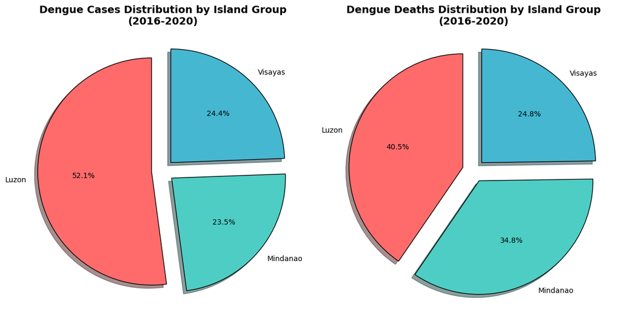

```
          Dengue_Cases  Dengue_Deaths  Cases_Percentage  Deaths_Percentage
Islands
Luzon           597864           6815              52.1               40.5
Mindanao        269372           5859              23.5               34.8
Visayas         280189           4170              24.4               24.8
```

```python
plt.figure(figsize=(12, 8))

island_totals = dengue.groupby('Islands')[['Dengue_Cases', 'Dengue_Deaths']].sum()
island_totals['Cases_Percentage'] = ((island_totals['Dengue_Cases'] / island_totals['Dengue_Cases'].sum()) * 100).round(1)
island_totals['Deaths_Percentage'] = ((island_totals['Dengue_Deaths'] / island_totals['Dengue_Deaths'].sum()) * 100).round(1)

# Create explode parameters to separate the slices
explode = (0.1, 0.1, 0.1)  # Separate all slices by 0.1


# Dengue Cases
plt.subplot(1, 2, 1)
plt.pie(island_totals['Dengue_Cases'], labels=island_totals.index, autopct='%1.1f%%', colors=['#FF6B6B', '#4ECDC4', '#45B7D1'], startangle=90, explode=explode, shadow=True, wedgeprops={'edgecolor': 'black', 'linewidth': 1})
plt.title('Dengue Cases Distribution by Island Group\n(2016-2020)', fontsize=14, fontweight='bold')


# Dengue Deaths
plt.subplot(1, 2, 2)
plt.pie(island_totals['Dengue_Deaths'], labels=island_totals.index, autopct='%1.1f%%', colors=['#FF6B6B', '#4ECDC4', '#45B7D1'], startangle=90, explode=explode, shadow=True, wedgeprops={'edgecolor': 'black', 'linewidth': 1})
plt.title('Dengue Deaths Distribution by Island Group\n(2016-2020)', fontsize=14, fontweight='bold')

plt.tight_layout()
plt.show()

print(island_totals)
```

ANALYSIS INSIGHT

Even though Luzon had the most total dengue cases at 597,864 and 6,815 deaths, the island of Mindanao needs the most urgent help. The real problem is how much more severe the outbreak is there. Mindanao had the fewest cases at 269,372, which is only 23.5% of the country's total. However, it had a shocking 5,859 deaths, which makes up 34.8% of all dengue fatalities in the country.

This means that if you got dengue in Mindanao, you were much more likely to die from it. This is shown by its "Case Fatality Rate" of 2.18%, which is almost double Luzon's rate of 1.14%. Basically, Luzon had over half the cases (52.1%) but only 40.5% of the deaths, while Visayas was in the middle.

The much higher death rate in Mindanao shows that the hospitals or medical care there are not working well enough. This means we need to help Mindanao first and fast to save the most lives.

## Question 2

### Was the fourth (4) quarter the time when dengue cases were at their highest in 2019 across the country?

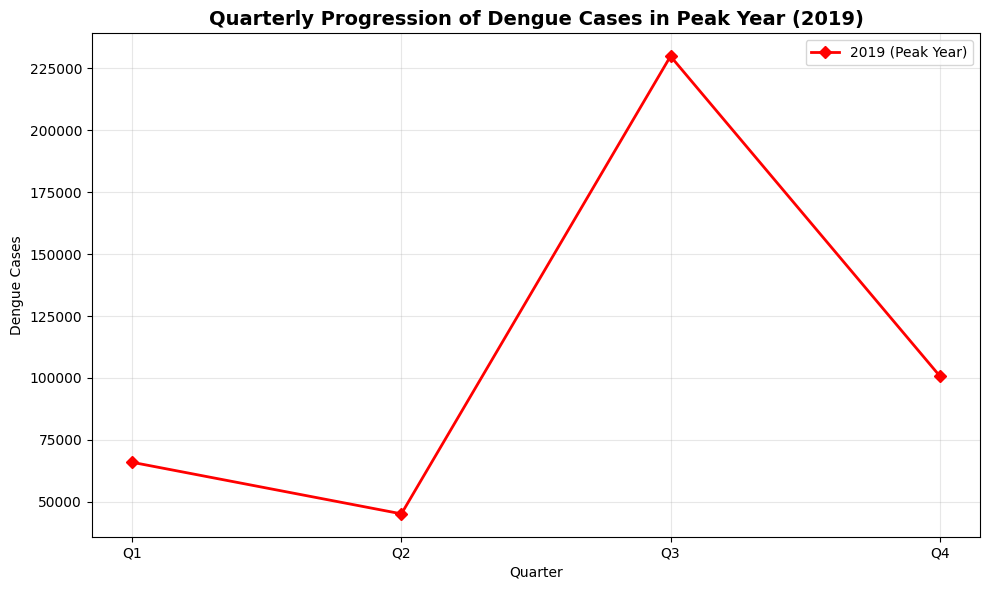

```
Quarter
Q1     65964
Q2     45162
Q3    229900
Q4    100876
Name: Dengue_Cases, dtype: int64
```

```python
dengue_2019 = dengue[dengue['Year'] == 2019]
quarterly_2019 = dengue_2019.groupby('Quarter')['Dengue_Cases'].sum().reindex(['Q1', 'Q2', 'Q3', 'Q4'])

plt.figure(figsize=(10, 6))
plt.plot(quarterly_2019.index, quarterly_2019.values, marker='D', linestyle='-', color='red', linewidth=2, label='2019 (Peak Year)')
plt.title('Quarterly Progression of Dengue Cases in Peak Year (2019)', fontsize=14, fontweight='bold')
plt.xlabel('Quarter')
plt.ylabel('Dengue Cases')
plt.legend()
plt.grid(True, alpha=0.3)
plt.tight_layout()
plt.show()

print(quarterly_2019)
```

ANALYSIS INSIGHT

No, the fourth quarter (Q4) was not the time when dengue cases were at their highest across the country during 2019. The third quarter (Q3) was actually the period with the most dengue cases. The outbreak reached its highest level in Q3 with 229,900 reported cases.

This number is more than double the 100,876 cases recorded in the following quarter (Q4) showing that the problem was most intense during the third quarter.

## Question 3

### If you were to predict dengue deaths for the next year in Region 7, which months would you focus on and why?

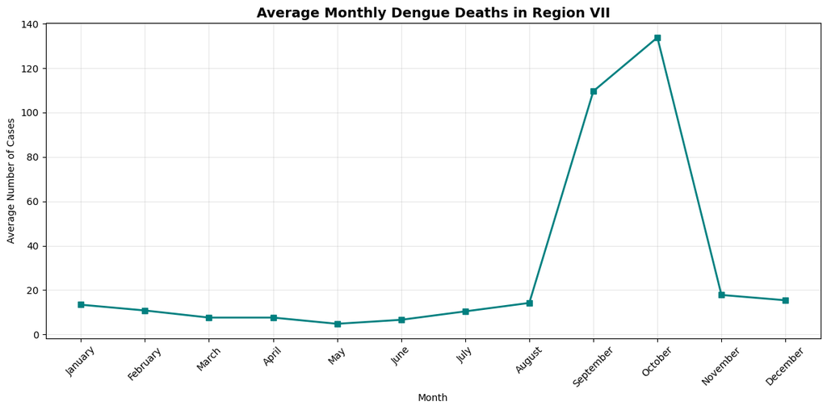

```
Month
January       13.4
February      10.8
March          7.6
April          7.6
May            4.8
June           6.6
July          10.4
August        14.2
September    109.6
October      133.8
November      17.8
December      15.4
Name: Dengue_Deaths, dtype: float64
```

```python
month_order = ['January', 'February', 'March', 'April', 'May', 'June', 'July', 'August', 'September', 'October', 'November', 'December']
region_data = dengue[dengue['Region'] == 'Region VII']
monthly_region = region_data.groupby('Month')['Dengue_Deaths'].mean().reindex(month_order)

plt.figure(figsize=(12, 6))
plt.plot(monthly_region.index, monthly_region.values, marker='s', color='teal', linewidth=2)
plt.title('Average Monthly Dengue Deaths in Region VII', fontsize=14, fontweight='bold')
plt.xlabel('Month')
plt.ylabel('Average Number of Cases')
plt.xticks(rotation=45)
plt.grid(True, alpha=0.3)
plt.tight_layout()
plt.show()

print(monthly_region)
```

ANALYSIS INSIGHT

To make accurate predictions and save lives, all our attention and resources must be directed at preparing for this specific two-month crisis.

## Question 4

### Do regions with more cases also have more deaths?

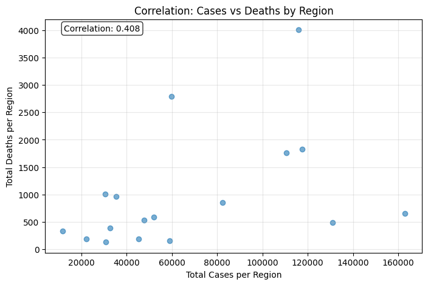

```
             Dengue_Cases  Dengue_Deaths
Region
BARMM               11537            332
CAR                 30582           1008
NCR                115966           4008
Region I            59066            157
Region II           45141            193
Region III         131064            482
Region IV-A        163029            652
Region IV-B         30849            130
Region IX           47781            532
Region V            22167            185
Region VI          117523           1825
Region VII         110683           1760
Region VIII         51983            585
Region X            82437            848
Region XI           32522            385
Region XII          59802           2796
Region XIII         35293            966
How strongly dengue cases and dengue deaths are related : 0.408%
```

```python
regional_totals = dengue.groupby('Region')[['Dengue_Cases', 'Dengue_Deaths']].sum()

plt.figure(figsize=(8, 5))
plt.scatter(regional_totals['Dengue_Cases'], regional_totals['Dengue_Deaths'], alpha=0.6)
plt.title('Correlation: Cases vs Deaths by Region')
plt.xlabel('Total Cases per Region')
plt.ylabel('Total Deaths per Region')

# Correlation value
correlation = regional_totals['Dengue_Cases'].corr(regional_totals['Dengue_Deaths'])
plt.text(0.05, 0.95, f'Correlation: {correlation:.3f}', transform=plt.gca().transAxes, bbox=dict(boxstyle="round,pad=0.3", facecolor="white", alpha=0.8))
plt.grid(True, alpha=0.3)
plt.show()

print(regional_totals)
print(f"How strongly dengue cases and dengue deaths are related : {correlation:.3f}%")
```

ANALYSIS INSIGHT

The connection between dengue cases and deaths is not very strong for the whole country. The correlation is only 0.408 which is a weak. This means that while more cases sometimes lead to more deaths, there are many big exceptions.

A high number of cases does not automatically mean a high number of deaths. The real reasons for the high death toll in some areas are likely due to other factors. These factors include poor healthcare quality, slow treatment for patients, and weak public health programs in those specific regions.

## Question 5

### Which months strain our hospital capacity the most?

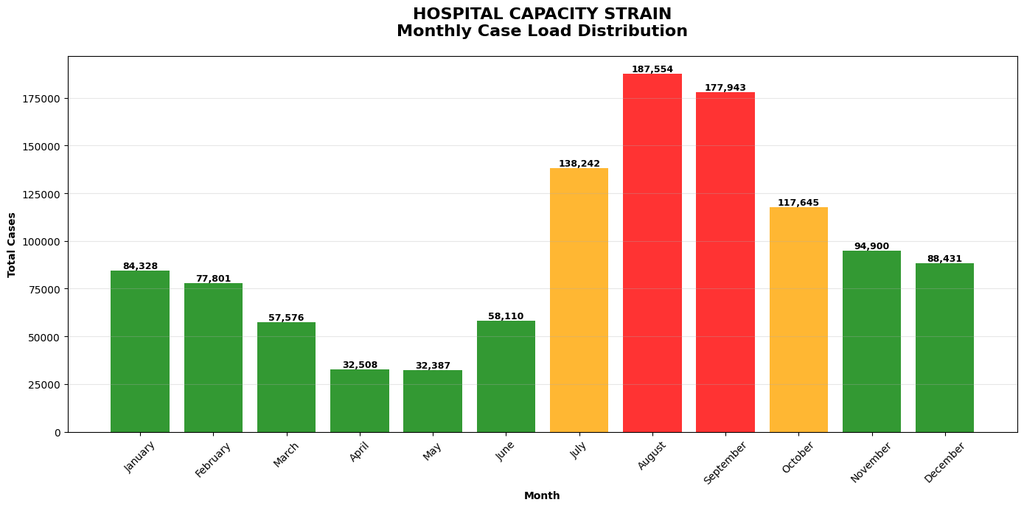

```python
monthly_totals = dengue.groupby('Month')['Dengue_Cases'].sum().reindex(month_order)

plt.figure(figsize=(14, 7))
colors = ['green' if x < monthly_totals.quantile(0.7) else 'orange' if x < monthly_totals.quantile(0.9) else 'red' for x in monthly_totals]

bars = plt.bar(monthly_totals.index, monthly_totals.values, color=colors, alpha=0.8)
plt.bar_label(bars, fmt='{:,.0f}', fontsize=9, fontweight='bold')

plt.title('HOSPITAL CAPACITY STRAIN\nMonthly Case Load Distribution', fontsize=16, fontweight='bold', pad=20)
plt.xlabel('Month', fontweight='bold')
plt.ylabel('Total Cases', fontweight='bold')
plt.xticks(rotation=45)
plt.grid(axis='y', alpha=0.3)
plt.tight_layout()
plt.show()
```

ANALYSIS INSIGHT

Hospitals are under the most strain during July, August, September. These three months had a huge wave of dengue cases that was much higher than the rest of the year. Specifically, August had about 187,554 cases, September had about 177,943 cases, and July had about 138,242 cases. The patient numbers in August and September were more than double the caseload of most other months.

After September, the number of cases went down. October had about 117,645 cases. This means October had only 66% of the cases that September had.

So, while things got better in October, the high number of sick people during the three-month period creates the greatest demand for hospital beds, doctors, and medical equipment. This makes it the most important time for the healthcare system to be prepared.

## Question 6

### What might explain years when Visayas dengue deaths were below the national trend?

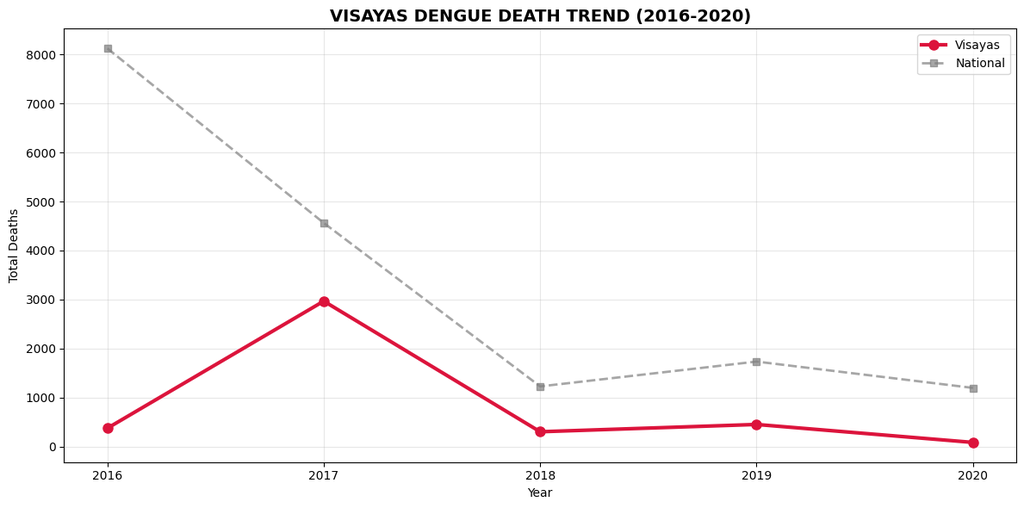

```
Visayas Dengue Deaths Per Year:
Year
2016     372
2017    2967
2018     300
2019     449
2020      82
Name: Dengue_Deaths, dtype: int64

National Dengue Deaths Per Year:
Year
2016    8127
2017    4563
2018    1226
2019    1733
2020    1195
Name: Dengue_Deaths, dtype: int64
```

```python
visayas_data = dengue[dengue['Islands'] == 'Visayas']
visayas_yearly = visayas_data.groupby('Year')['Dengue_Deaths'].sum()
national_yearly = dengue.groupby('Year')['Dengue_Deaths'].sum()

plt.figure(figsize=(12, 6))
plt.plot(visayas_yearly.index, visayas_yearly.values, marker='o', linewidth=3,label='Visayas', color='crimson', markersize=8)
plt.plot(national_yearly.index, national_yearly.values, marker='s', linewidth=2,label='National', color='gray', linestyle='--', alpha=0.7)

plt.title('VISAYAS DENGUE DEATH TREND (2016-2020)', fontweight='bold', fontsize=14)
plt.ylabel('Total Deaths')
plt.xlabel('Year')
plt.xticks(visayas_yearly.index)
plt.legend()
plt.grid(True, alpha=0.3)
plt.tight_layout()
plt.show()

print("Visayas Dengue Deaths Per Year:")
print(visayas_yearly)
print("\nNational Dengue Deaths Per Year:")
print(national_yearly)
```

ANALYSIS INSIGHT

The best explanation for 2020 is the COVID 19 lockdowns, which likely reduced mosquito breeding and human contact. For 2016 and 2018, the low numbers were probably due to a combination of successful local mosquito control programs, less rain, or just the virus was not as widespread there in those specific years.

## Question 7

### Does the data confirm that dengue is climate-sensitive?

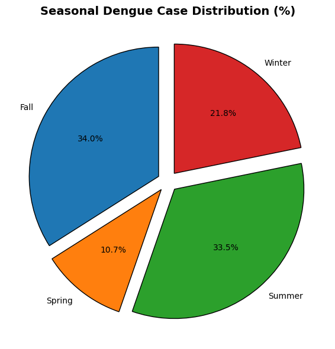

```
Season
Fall      34.0
Spring    10.7
Summer    33.5
Winter    21.8
Name: Dengue_Cases, dtype: float64
```

```python
seasonal_pct = (dengue.groupby('Season')['Dengue_Cases'].sum() / dengue['Dengue_Cases'].sum() * 100).round(1)

plt.figure(figsize=(8, 6))
explode = [0.08] * len(seasonal_pct)
plt.pie(seasonal_pct, labels=seasonal_pct.index, autopct='%1.1f%%',startangle=90, explode=explode, wedgeprops={'edgecolor': 'black'})
plt.title('Seasonal Dengue Case Distribution (%)', fontsize=14, fontweight='bold')
plt.tight_layout()
plt.show()

print(seasonal_pct)
```

ANALYSIS INSIGHT

Cases go up in the warm, wet weather and go down in the cool, dry weather, confirms that the local climate is a key factor in when dengue outbreaks happen.

## Question 8

### Which Mindanao regions require more aggressive dengue control strategies in 2018?

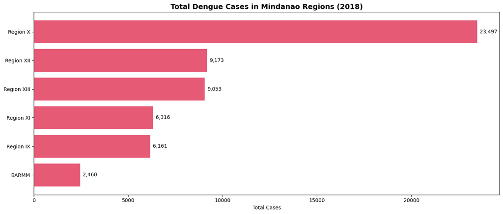

```
Region
BARMM           2460
Region IX       6161
Region XI       6316
Region XIII     9053
Region XII      9173
Region X       23497
Name: Dengue_Cases, dtype: int64
```

```python
mindanao_2018 = dengue[(dengue['Islands'] == 'Mindanao') & (dengue['Year'] == 2018)]
region_cases_2018 = mindanao_2018.groupby('Region')['Dengue_Cases'].sum().sort_values()

plt.figure(figsize=(14, 6))
bars = plt.barh(region_cases_2018.index, region_cases_2018.values, color='crimson', alpha=0.7)
plt.bar_label(bars, labels=[f'{v:,}' for v in region_cases_2018.values], padding=5)
plt.title('Total Dengue Cases in Mindanao Regions (2018)', fontsize=14, fontweight='bold')
plt.xlabel('Total Cases')
plt.tight_layout()
plt.show()

print(region_cases_2018)
```

ANALYSIS INSIGHT

These areas still need attention, but the most resources and the most aggressive control strategies should go first to Region X, then to Regions XII and XIII, to stop the outbreak.

## Question 9

### Could delays in diagnosis and treatment in some regions have contributed to higher dengue mortality during the 2017 outbreak?

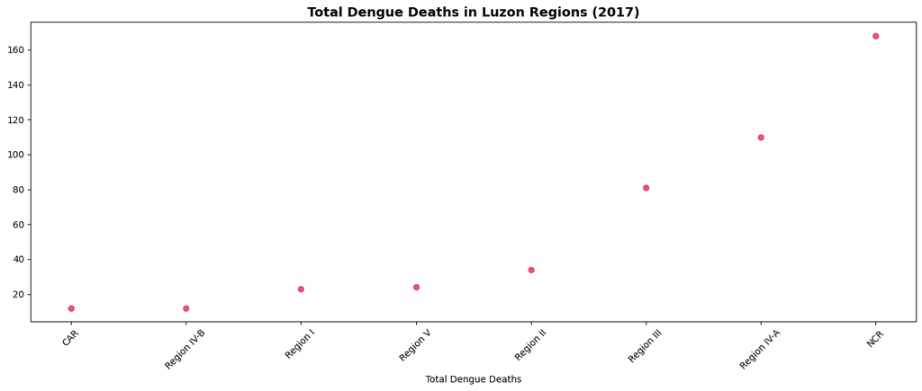

```
Region
CAR             12
Region IV-B     12
Region I        23
Region V        24
Region II       34
Region III      81
Region IV-A    110
NCR            168
Name: Dengue_Deaths, dtype: int64
```

```python
luzon_2017 = dengue[(dengue['Islands'] == 'Luzon') & (dengue['Year'] == 2017)]
region_cases_2017 = luzon_2017.pivot_table(values='Dengue_Deaths', index='Region', aggfunc='sum').squeeze().sort_values(ascending=True)

plt.figure(figsize=(14, 6))
plt.scatter(region_cases_2017.index, region_cases_2017.values, color='crimson', alpha=0.7)
plt.title('Total Dengue Deaths in Luzon Regions (2017)', fontsize=14, fontweight='bold')
plt.xlabel('Total Dengue Deaths')
plt.xticks(rotation=45)
plt.tight_layout()
plt.show()

print(region_cases_2017)
```

ANALYSIS INSIGHT

Yes, some regions saw dengue deaths in 2017 due to delays in diagnosing and treating the disease. The National Capital Region had the most deaths by far, with 168. This is more than 50 percent higher than the next region, Region IV-A, which had 110 deaths. This is important because the capital has the best hospitals. The reason might be that it was so overwhelmed with patients that even good hospitals experienced delays. But the most telling fact is when we look at other regions.

Many deaths in the capital were due to high case numbers, while uneven deaths elsewhere tells us treatment delays played a major role in the 2017 outbreak.

## Question 10

### What region shows a critical need for dengue emergency response systems?

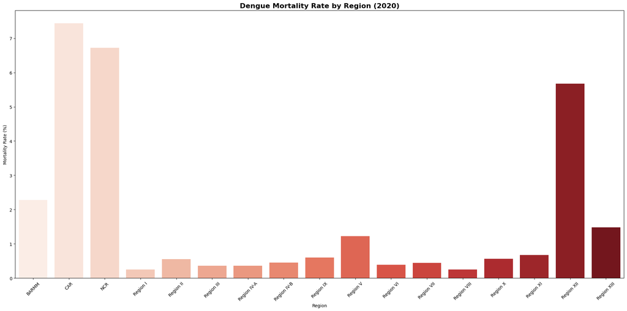

```
         Region  Dengue_Deaths  Dengue_Cases  Mortality_Rate
0         BARMM             23          1008            2.28
1           CAR             73           981            7.44
2           NCR            483          7183            6.72
3      Region I             18          7171            0.25
4     Region II              9          1628            0.55
5    Region III             57         15991            0.36
6   Region IV-A             35          9721            0.36
7   Region IV-B             23          5077            0.45
8     Region IX             16          2684            0.60
9      Region V             21          1721            1.22
10    Region VI             16          4131            0.39
11   Region VII             54         12406            0.44
12  Region VIII             12          4832            0.25
13     Region X             35          6225            0.56
14    Region XI             13          1936            0.67
15   Region XII            248          4363            5.68
16  Region XIII             59          3983            1.48
```

```python
dengue_2020 = dengue[dengue["Year"] == 2020]
regions_death_rate_2020 = dengue_2020.groupby("Region")[["Dengue_Deaths", "Dengue_Cases"]].sum().reset_index()
regions_death_rate_2020["Mortality_Rate"] = np.round((regions_death_rate_2020["Dengue_Deaths"] / regions_death_rate_2020["Dengue_Cases"]) * 100, 2)

plt.figure(figsize=(20, 10))
sns.barplot(data=regions_death_rate_2020, x="Region", y="Mortality_Rate", palette="Reds")
plt.title("Dengue Mortality Rate by Region (2020)", fontsize=16, fontweight="bold")
plt.xlabel("Region")
plt.ylabel("Mortality Rate (%)")
plt.xticks(rotation=45)
plt.tight_layout()
plt.show()

print(regions_death_rate_2020)
```

ANALYSIS INSIGHT

The Cordillera Administrative Region (CAR) needs a dengue emergency system most urgently. It has a mortality rate of 7.44% which is the highest among all regions. This means for every 100 people sick with dengue in CAR, about 7 die. In comparison, the National Capital Region (NCR) had more total deaths (483), but a lower mortality rate of 6.72%.

CAR's mortality rate is a sign that its healthcare system is failing. It shows people are not getting diagnosed or treated in time. This makes CAR the most critical priority for an emergency response to stop these preventable deaths.

**Data Analysis by:** Jomel Tomeo

**Institution/Organization:** Dalubhasaan ng Lungsod ng Lucena

**Date:** October 16, 2025

© 2025 All rights reserved. This analysis is prepared exclusively for academic and professional purposes. No part of this work may be reproduced, distributed, or transmitted without prior permission.